# Data_605_Final

# Probability

Calculate as a minimum the below probabilities a through c. Assume the small letter “x” is estimated as the 3d quartile of the X variable, and the small letter “y” is estimated as the 2d quartile of the Y variable. Interpret the meaning of all probabilities. In addition, make a table of counts as shown below.

1. P(X>x | Y>y)
2. P(X>x, Y>y)
3. P(X<x | Y>y)

```r
# to see quartiles for X

summary(X)
```

```
##    Min. 1st Qu.  Median    Mean 3rd Qu.    Max.
##    1300    7554    9478   10517   11602  215245
```

```r
# to assign 3rd quartile new variable x_3q

x_3q <- summary(X)["3rd Qu."]
```

```r
# to see quartiles for Y

summary(Y)
```

```
##    Min. 1st Qu.  Median    Mean 3rd Qu.    Max.
##   34900  129975  163000  180921  214000  755000
```

```r
# to assign 2nd quartile to new variable y_2q, median(163000)

y_2q <- summary(Y)["Median"]
```

1. P(X>x | Y>y)

```r
# to define a new binary variable X_1 based on the condition that the original variable X is greater than some threshold value x_3q
# to define another binary variable Y_1 based on the condition that the original variable Y is greater than another threshold value y_2q
# to count how many times both X_1 and Y_1 are equal to 1
# to compute the sum of Y_1, which represents the total count of occurrences where Y_1 is true
# we calculate the ratio n/d (numerator / denominator)

X_1 <- X > x_3q
Y_1 <- Y > y_2q
n <- sum(X_1 & Y_1)
d <- sum(Y_1)
n/d
```

```
## [1] 0.3791209
```

2. P(X>x, Y>y)

```r
# to count how many times both X_1 and Y_1 are equal to 1
# to represent the total number of rows in the dataset train.
# to calculate the ratio

n <- sum(X_1 & Y_1)
d <- nrow(train)
n/d
```

```
## [1] 0.1890411
```

3. P(X<x | Y>y)

```r
# to create the condition that the original variable X is less than some threshold value x_3q
# to create a another variable Y_2 based on the condition that the original variable Y is greater than another threshold value y_2q
# to count how many times both X_2 and Y_1 are equal to 1
# to computes the sum of Y_1, which represents the total count of occurrences where Y_1 is true
# to calculate the ratio

X_2 <- X < x_3q
Y_2 <- Y > y_2q
n <- sum(X_2 & Y_1)
d <- sum(Y_1)
n/d
```

```
## [1] 0.6208791
```

```r
# to build the table

table_count <- matrix(0, nrow = 3, ncol = 3)
colnames(table_count) <- c("<=2d quartile", ">2d quartile", "Total")
rownames(table_count) <- c("<=3d quartile", ">3d quartile", "Total")

table_count[1, 1] <- sum(X <= x_3q & Y <= y_2q)
table_count[1, 2] <- sum(X <= x_3q & Y > y_2q)
table_count[1, 3] <- table_count[1, 1] + table_count[1, 2]
table_count[2, 1] <- sum(X > x_3q & Y <= y_2q)
table_count[2, 2] <- sum(X > x_3q & Y > y_2q)
table_count[2, 3] <- table_count[2, 1] + table_count[2, 2]
table_count[3, 1] <- table_count[1, 1] + table_count[2, 1]
table_count[3, 2] <- table_count[1, 2] + table_count[2, 2]
table_count[3, 3] <- table_count[1, 3] + table_count[2, 3]

print(table_count)
```

```
##               <=2d quartile >2d quartile Total
## <=3d quartile           643          452  1095
## >3d quartile             89          276   365
## Total                   732          728  1460
```

```r
# to check the sums of each variable

sum(X_1)
```

```
## [1] 365
```

```r
sum(Y_1)
```

```
## [1] 728
```

```r
sum(X_2)
```

```
## [1] 1095
```

```r
sum(Y_2)
```

```
## [1] 728
```

# Does splitting the training data in this fashion make them independent?

No, does not change the relationship between X and Y, thus it does not make them independent of one another.

Let A be the new variable counting those observations above the 3d quartile for X, and let B be the new variable counting those observations above the 2d quartile for Y. Does P(A|B)=P(A)P(B)? Check mathematically, and then evaluate by running a Chi Square test for association.

```r
# assigning new variable A and B

A <- X > x_3q
B <- Y > y_2q

#  probability(A|B)

P_A_given_B <- sum(A * B) / sum(B)
P_A_given_B
```

```
## [1] 0.3791209
```

```r
P_A <- sum(A) / length(A)
P_B <- sum(B) / length(B)
P_A * P_B
```

```
## [1] 0.1246575
```

# Does P(A|B)=P(A)P(B)?

No the probability of A | B is 37.9 and probability of A * B is 12.4%, and they are not equal mathematically.

# Chi Square test for association.

```r
# to create chi-squared test on the contingency table, to tests the null hypothesis

chi_test <- chisq.test(table(A, B))
print(chi_test)
```

```
##
##  Pearson's Chi-squared test with Yates' continuity correction
##
## data:  table(A, B)
## X-squared = 127.74, df = 1, p-value < 2.2e-16
```

Given the p-value, we would reject the null hypothesis of A and B being equal.

# Descriptive and Inferential Statistics.

Provide univariate descriptive statistics and appropriate plots for the training data set. Provide a scatterplot of X and Y. Provide a 95% CI for the difference in the mean of the variables. Derive a correlation matrix for two of the quantitative variables you selected. Test the hypothesis that the correlation between these variables is 0 and provide a 99% confidence interval. Discuss the meaning of your analysis.

## Provide univariate descriptive statistics and appropriate plots for the training data set

```r
# to see the summaries for both X and Y

summary(X)
```

```
##    Min. 1st Qu.  Median    Mean 3rd Qu.    Max.
##    1300    7554    9478   10517   11602  215245
```

```r
summary(Y)
```

```
##    Min. 1st Qu.  Median    Mean 3rd Qu.    Max.
##   34900  129975  163000  180921  214000  755000
```

## Provide a scatterplot of X and Y

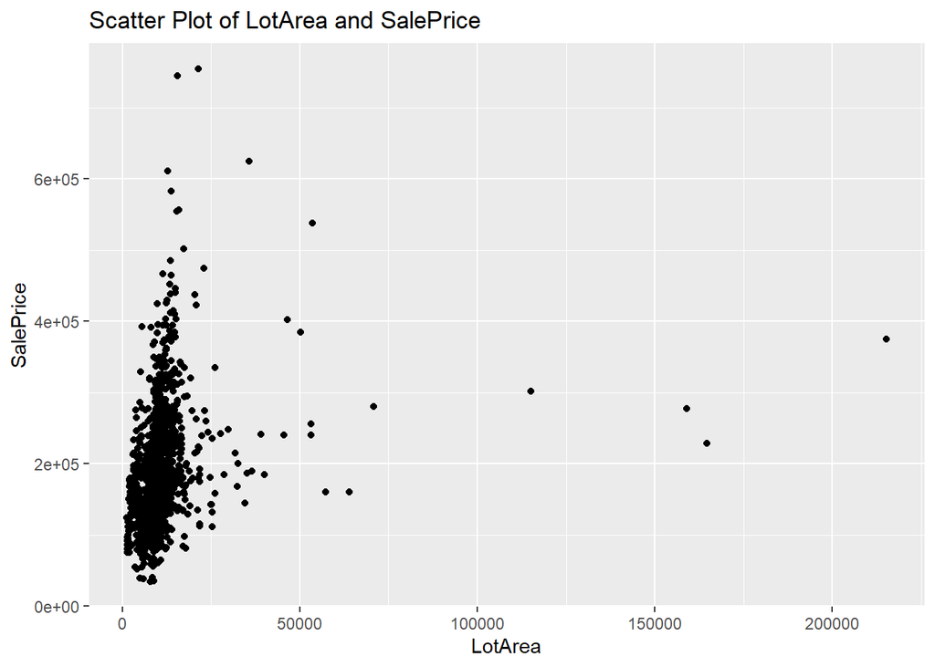

```r
# X is LotArea
# Y is SalePrice
# to create a scatter plot

ggplot(train, aes(x = X, y = Y)) +
  geom_point() +
  labs(x = "LotArea", y = "SalePrice", title = "Scatter Plot of LotArea and SalePrice")
```

## Provide a 95% CI for the difference in the mean of the variables

```r
# to create a t test for 95% confidence interval

t.test(X, Y, conf.level = 0.95)
```

```
##
##  Welch Two Sample t-test
##
## data:  X and Y
## t = -81.321, df = 1505.1, p-value < 2.2e-16
## alternative hypothesis: true difference in means is not equal to 0
## 95 percent confidence interval:
##  -174514.7 -166294.1
## sample estimates:
## mean of x mean of y
##  10516.83 180921.20
```

95 percent confidence interval: -174514.7 -166294.1

## Derive a correlation matrix for two of the quantitative variables you selected

```r
# to create a new dataset with only the two variables LotArea and SalePrice
# to create correlation martrix

train2 <- train %>%
        dplyr::select(LotArea, SalePrice)

corr_matrix = cor(train2)

corr_matrix
```

```
##             LotArea SalePrice
## LotArea   1.0000000 0.2638434
## SalePrice 0.2638434 1.0000000
```

## Test the hypothesis that the correlation between these variables is 0 and provide a 99% confidence interval.

```r
# to calculate the Pearson correlation coefficient between LotArea and SalePrice variables, along with a 99% confidence interval for the correlation

corr_test <- cor.test(train2$LotArea, train2$SalePrice, method = "pearson", conf.level = 0.99)
print(corr_test)
```

```
##
##  Pearson's product-moment correlation
##
## data:  train2$LotArea and train2$SalePrice
## t = 10.445, df = 1458, p-value < 2.2e-16
## alternative hypothesis: true correlation is not equal to 0
## 99 percent confidence interval:
##  0.2000196 0.3254375
## sample estimates:
##       cor
## 0.2638434
```

## Discuss the meaning of your analysis.

Significant correlation between X and Y, because the P-value of 2.2e-16 is less than the .01 level of significance provided. Therefore we reject the null hypothesis.

# Linear Algebra and Correlation

Invert your correlation matrix. (This is known as the precision matrix and contains variance inflation factors on the diagonal.) Multiply the correlation matrix by the precision matrix, and then multiply the precision matrix by the correlation matrix. Conduct principle components analysis (research this!) and interpret. Discuss.

## Invert your correlation matrix. (This is known as the precision matrix and contains variance inflation factors on the diagonal.)

```r
# to compute the inverse of the correlation matrix (corr_matrix) and assign it to the variable pres_matrix

pres_matrix <- solve(corr_matrix)
pres_matrix
```

```
##              LotArea  SalePrice
## LotArea    1.0748219 -0.2835846
## SalePrice -0.2835846  1.0748219
```

```r
# to calculate the product of the correlation matrix and its inverse

round(corr_matrix %*% pres_matrix)
```

```
##           LotArea SalePrice
## LotArea         1         0
## SalePrice       0         1
```

## Conduct principle components analysis (research this!)

```r
# to calculate the average correlation coefficient between all numeric variables in dataset train2

mean(cor(train2))
```

```
## [1] 0.6319217
```

## Conduct principle components analysis (research this!) and interpret. Discuss.

```r
# to perform principal component analysis (PCA) on the dataset train2 using the princomp function

pca_res <- princomp(train2)
pca_res$loadings
```

```
##
## Loadings:
##           Comp.1 Comp.2
## LotArea           0.999
## SalePrice  0.999
##
##                Comp.1 Comp.2
## SS loadings       1.0    1.0
## Proportion Var    0.5    0.5
## Cumulative Var    0.5    1.0
```

```r
# to create summary of results from principal component analysis (PCA) performed on dataset train2

summary(pca_res)
```

```
## Importance of components:
##                              Comp.1       Comp.2
## Standard deviation     7.945956e+04 9.618924e+03
## Proportion of Variance 9.855575e-01 1.444251e-02
## Cumulative Proportion  9.855575e-01 1.000000e+00
```

Principle Comp. 1 explains the larger proportion of the shared variance between the `LotArea` and `SalePrice` (0.986). Principle Comp. 2 explains the smaller proportion of the two variables (0.014) The loading explains how much of the variation of the variables is explained by the components.

# Calculus-Based Probability & Statistics

Many times, it makes sense to fit a closed form distribution to data. For your variable that is skewed to the right, shift it so that the minimum value is above zero. Then load the MASS package and run fitdistr to fit an exponential probability density function. (See https://stat.ethz.ch/R-manual/R-devel/library/MASS/html/fitdistr.html ). Find the optimal value of  for this distribution, and then take 1000 samples from this exponential distribution using this value (e.g., rexp(1000, )). Plot a histogram and compare it with a histogram of your original variable. Using the exponential pdf, find the 5th and 95th percentiles using the cumulative distribution function (CDF). Also generate a 95% confidence interval from the empirical data, assuming normality. Finally, provide the empirical 5th percentile and 95th percentile of the data. Discuss.

## For your variable that is skewed to the right, shift it so that the minimum value is above zero.

```r
# to calculate summary of the values in the LotArea variable from the dataset train

X <- train$LotArea
summary(X)
```

```
##    Min. 1st Qu.  Median    Mean 3rd Qu.    Max.
##    1300    7554    9478   10517   11602  215245
```

I chose not to shift because the minimum value is above zero (1300).

## Find the optimal value of λ for this distribution, and then take 1000 samples from this exponential distribution using this value (e.g., rexp(1000, λ)).

```r
# to estimate the rate parameter (λ) for an exponential distribution

exp_prob_den <- fitdistr(X, "exponential")
exp_prob_den
```

```
##        rate
##   9.508570e-05
##  (2.488507e-06)
```

```r
lambda <- exp_prob_den$estimate
lambda
```

```
##        rate
## 9.50857e-05
```

```r
# to generate a random sample of 1000 values from an exponential distribution

samp <- rexp(1000, rate = lambda)
```

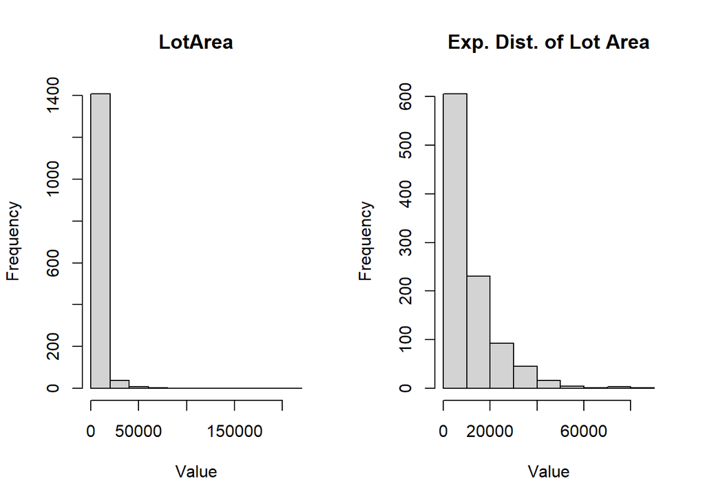

```r
# to create a side-by-side comparison of histograms for the variable LotArea

par(mfrow = c(1, 2))
hist(X, main = "LotArea", xlab = "Value")
hist(samp, main = "Exp. Dist. of Lot Area", xlab = "Value")
```

# Using the exponential pdf, find the 5th and 95th percentiles using the cumulative distribution function (CDF).

```r
# to  calculate 5th percentile (lower quantile) and 95th percentile (upper quantile) of sample generated from exponential distribution

quantile(samp, probs = c(0.05, 0.95))
```

```
##         5%        95%
##   663.4439 34537.5411
```

# Also generate a 95% confidence interval from the empirical data, assuming normality

```r
# to calculate a 95% confidence interval

m <- mean(samp)
s <- sd(samp)
se <- s/sqrt(1000)

lower <- m - 1.96 * se
lower
```

```
## [1] 10318.7
```

```r
upper <- m + 1.96 * se
upper
```

```
## [1] 11722.7
```

# Finally, provide the empirical 5th percentile and 95th percentile of the data. Discuss.

```r
# to calculate 5th percentile (lower quantile) and 95th percentile (upper quantile) of variable X

quantile(X, probs = c(0.05, 0.95))
```

```
##       5%      95%
##  3311.70 17401.15
```

The spread of the distribution of `LotArea` got a lot wider after exponentiation. As evidenced by the range of values in the middle 90% of the data. Additionally, `LotArea` was originally not normally distributed, and it is still not normally distributed after turning it into an exponential distribution, but is is more spread.

# Modeling. Build some type of regression model and submit your model to the competition board. Provide your complete model summary and results with analysis. Report your Kaggle.com user name and score.

```r
# to create new data frame train3 by selecting columns SalePrice, LotArea, LotFrontage, YearBuilt, YearRemodAdd, OverallQual, OverallCond, BldgType, BedroomAbvGr, GarageCars, and BsmtFinSF1
# to replaces missing values in GarageCars and BsmtFinSF1 columns with zeros and remove any rows with missing values NA

train3 <- train %>%
  dplyr::select(SalePrice, LotArea, LotFrontage, YearBuilt, YearRemodAdd, OverallQual, OverallCond, BldgType, BedroomAbvGr, GarageCars, BsmtFinSF1) %>%
  mutate(GarageCars = ifelse(is.na(GarageCars), 0, GarageCars),
         BsmtFinSF1 = ifelse(is.na(BsmtFinSF1), 0, BsmtFinSF1)) %>%
  drop_na()
```

```r
# to fit a linear regression model (lm) with the natural logarithm of the SalePrice as the response variable and all other variables in the train3 dataset as predictors

mod <- lm(log(SalePrice) ~ ., data = train3)

summary(mod)
```

```
##
## Call:
## lm(formula = log(SalePrice) ~ ., data = train3)
##
## Residuals:
##      Min       1Q   Median       3Q      Max
## -1.71065 -0.08876 -0.00138  0.09791  0.54231
##
## Coefficients:
##                  Estimate Std. Error t value Pr(>|t|)
## (Intercept)     2.388e+00  6.178e-01   3.866 0.000117 ***
## LotArea         4.232e-06  7.249e-07   5.837 6.84e-09 ***
## LotFrontage     2.198e-04  2.766e-04   0.795 0.426916
## YearBuilt       1.964e-03  2.714e-04   7.237 8.22e-13 ***
## YearRemodAdd    2.100e-03  3.467e-04   6.057 1.85e-09 ***
## OverallQual     1.440e-01  5.417e-03  26.584  < 2e-16 ***
## OverallCond     3.561e-02  5.650e-03   6.301 4.15e-10 ***
## BldgType2fmCon -2.653e-02  3.484e-02  -0.762 0.446464
## BldgTypeDuplex -5.931e-02  2.756e-02  -2.152 0.031569 *
## BldgTypeTwnhs  -1.613e-01  3.172e-02  -5.085 4.28e-07 ***
## BldgTypeTwnhsE -3.413e-02  2.281e-02  -1.497 0.134741
## BedroomAbvGr    7.327e-02  7.084e-03  10.342  < 2e-16 ***
## GarageCars      1.111e-01  8.861e-03  12.536  < 2e-16 ***
## BsmtFinSF1      1.321e-04  1.207e-05  10.943  < 2e-16 ***
## ---
## Signif. codes:  0 '***' 0.001 '**' 0.01 '*' 0.05 '.' 0.1 ' ' 1
##
## Residual standard error: 0.1759 on 1187 degrees of freedom
## Multiple R-squared:  0.8232, Adjusted R-squared:  0.8213
## F-statistic: 425.1 on 13 and 1187 DF,  p-value: < 2.2e-16
```

The coefficients represent the impact of each predictor variable on the log(SalePrice), such as the variable OverallQual is approximately 0.144, which means that for every one-unit increase in the overall quality rating, the log(SalePrice) increases by about 0.144 units. The Multiple R-squared value of 0.8232, shows that approximately 82.32% of the variance in the log(SalePrice) can be explained by the predictor variables in the model, suggesting that the model fits the data reasonably well.The Adjusted R-squared of 0.8213 adjusts for the number of predictors in the model, and is slightly lower than the Multiple R-squared which provides a more conservative estimate of the model’s fit. The F-statistic of 425.1 tests if any of the predictor variables significantly contribute to explaining the variance in the response variable. The p-value of < 2.2e-16 indicates strong evidence against the null hypothesis. And the model appears to be statistically significant.

```r
# to use step function on the model, resulting in a modified model

final <- step(mod)
```

```r
# to create summary(final) of final model

summary(final)
```

```
##
## Call:
## lm(formula = log(SalePrice) ~ LotArea + YearBuilt + YearRemodAdd +
##     OverallQual + OverallCond + BldgType + BedroomAbvGr + GarageCars +
##     BsmtFinSF1, data = train3)
##
## Residuals:
##      Min       1Q   Median       3Q      Max
## -1.67613 -0.09048 -0.00127  0.09733  0.54652
##
## Coefficients:
##                  Estimate Std. Error t value Pr(>|t|)
## (Intercept)     2.385e+00  6.176e-01   3.862 0.000119 ***
## LotArea         4.386e-06  6.985e-07   6.279 4.77e-10 ***
## YearBuilt       1.975e-03  2.710e-04   7.287 5.74e-13 ***
## YearRemodAdd    2.095e-03  3.466e-04   6.046 1.99e-09 ***
## OverallQual     1.444e-01  5.391e-03  26.787  < 2e-16 ***
## OverallCond     3.546e-02  5.646e-03   6.279 4.76e-10 ***
## BldgType2fmCon -2.711e-02  3.483e-02  -0.778 0.436463
## BldgTypeDuplex -5.974e-02  2.755e-02  -2.169 0.030317 *
## BldgTypeTwnhs  -1.703e-01  2.960e-02  -5.754 1.11e-08 ***
## BldgTypeTwnhsE -4.064e-02  2.128e-02  -1.910 0.056393 .
## BedroomAbvGr    7.387e-02  7.042e-03  10.491  < 2e-16 ***
## GarageCars      1.118e-01  8.819e-03  12.672  < 2e-16 ***
## BsmtFinSF1      1.336e-04  1.193e-05  11.192  < 2e-16 ***
## ---
## Signif. codes:  0 '***' 0.001 '**' 0.01 '*' 0.05 '.' 0.1 ' ' 1
##
## Residual standard error: 0.1759 on 1188 degrees of freedom
## Multiple R-squared:  0.8231, Adjusted R-squared:  0.8213
## F-statistic: 460.7 on 12 and 1188 DF,  p-value: < 2.2e-16
```

After stepping through the model, the final model is not significantly different from the initial regression model, indicating the initial fit was already a reasonable model. The only notable difference is in the F-statistic, went up from 425.1 to 460.7 now. Which would indicate that the final model’s predictor variables do a better job of explaining the variance in the response variable.

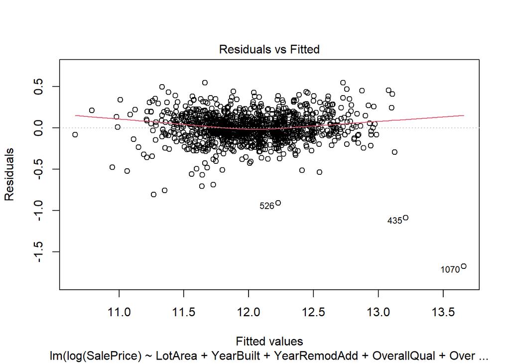

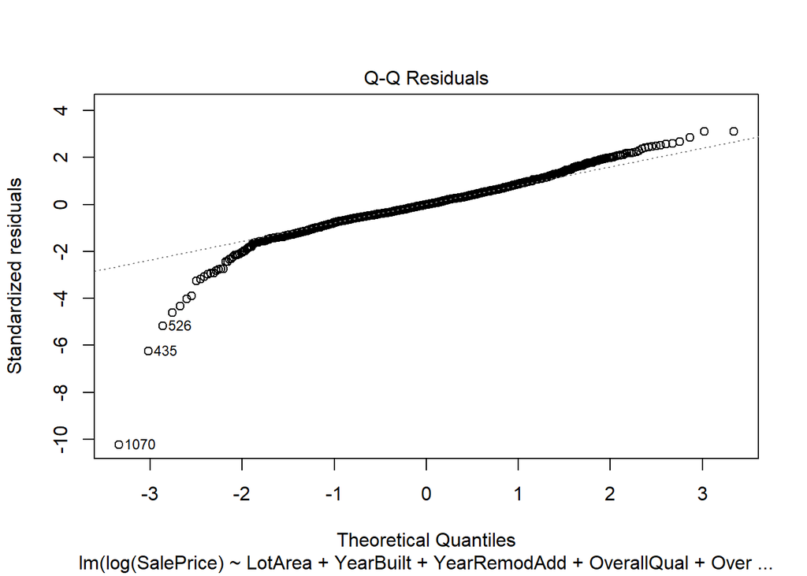

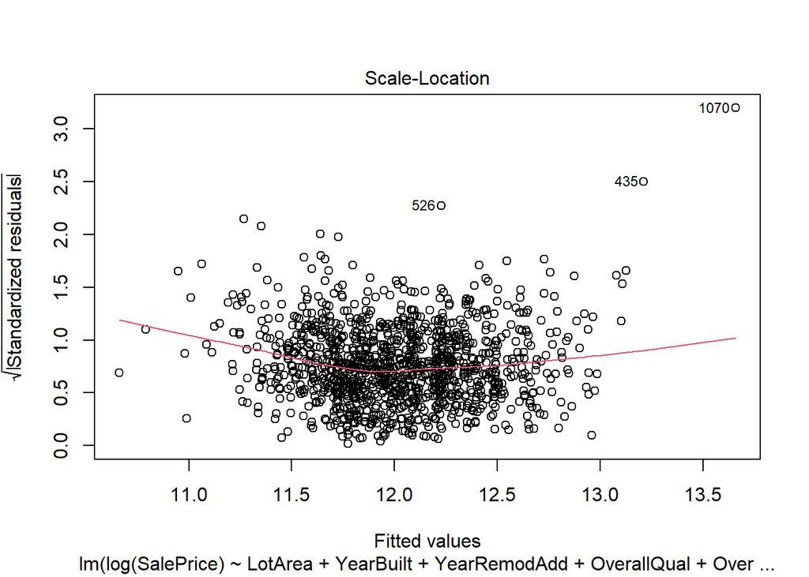

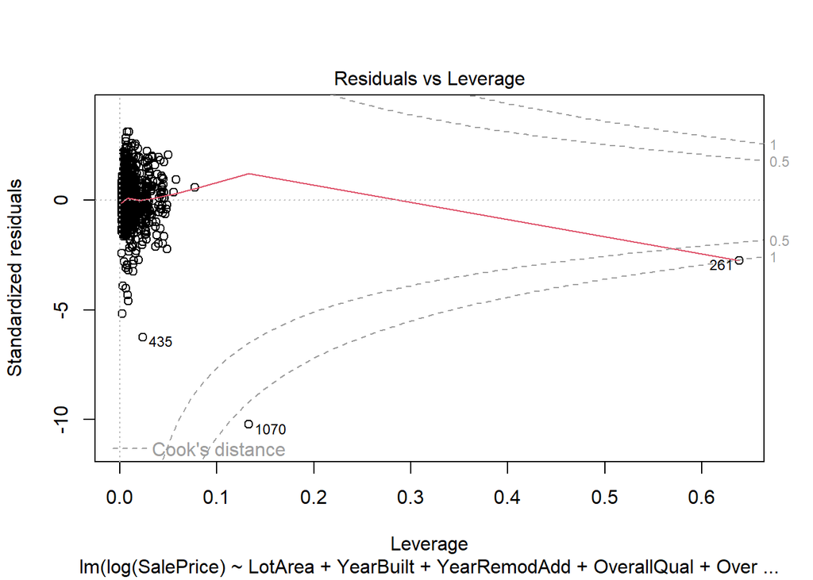

```r
# to plot the final models performance

plot(final)
```

```r
# to reas int he test data CSV file named “test.csv,” then replaces missing values in the “GarageCars” and “BsmtFinSF1” columns with zeros using the mutate function

test <- read.csv("C:\\Users\\akhay\\OneDrive\\Documents\\DATA_SCIENCE\\DATA 605\\Final\\test.csv")

test <- test %>%
  mutate(GarageCars = ifelse(is.na(GarageCars), 0, GarageCars),
         BsmtFinSF1 = ifelse(is.na(BsmtFinSF1), 0, BsmtFinSF1))
```

```r
# to predict house sale prices using the final regression model and the data from the “test.csv” file and  transforms the predictions by taking the exponential function that creates a data frame with columns “Id” and “SalePrice”

pred <- predict(final, newdata = test)
pred <- exp(pred)
df <- data.frame(test$Id, pred)
names(df) <- c("Id", "SalePrice")
head(df)
```

```
##     Id SalePrice
## 1 1461  117593.2
## 2 1462  155350.1
## 3 1463  167144.1
## 4 1464  192206.4
## 5 1465  201526.9
## 6 1466  168098.8
```

```r
# to write the predictions from the df data frame to a CSV file named sample_submission.csv

write.csv(df, file = "sample_submission.csv", row.names = FALSE, quote = FALSE)
```

# KAGGLE COMPETITION SUBMISSION SCORE

sample_submission.csv

Score: 0.17234